# dsci_II_project

Heather Lu

2026-03-25

# Load Data

```r
load("datA.RData")
str(datA)
```

```
## 'data.frame':    2000 obs. of  17 variables:
##  $ id              : chr  "A0001" "A0002" "A0003" "A0004" ...
##  $ age             : num  61.2 42 56.7 54 47 25 46.2 42.8 56.4 49.3 ...
##  $ menopause       : int  1 0 1 1 0 0 0 0 1 1 ...
##  $ race            : int  1 1 1 1 3 1 1 3 1 1 ...
##  $ bmi             : num  31.8 24 34.4 18.7 22.2 27.1 28.9 27 28.8 29.5 ...
##  $ tumor_size      : num  4.8 4.3 4.5 5.1 2.2 4.8 1.5 3 2.7 1.7 ...
##  $ tumor_grade     : int  3 3 1 2 1 3 2 2 1 2 ...
##  $ lymph_nodes     : int  6 2 2 11 0 6 0 1 0 1 ...
##  $ ER              : int  1 1 1 1 0 0 1 1 0 1 ...
##  $ PR              : int  1 1 1 1 0 0 1 1 0 1 ...
##  $ HER2            : int  0 0 1 0 0 0 0 0 1 0 ...
##  $ Ki67            : num  27.6 22.7 5 15.6 23.1 45.9 17.5 27.1 24.7 16.4 ...
##  $ stage           : int  3 3 2 3 1 3 1 1 2 1 ...
##  $ surgery         : int  1 0 0 1 0 0 0 0 1 0 ...
##  $ chemo           : int  1 1 0 1 1 0 0 0 1 0 ...
##  $ hormonal_therapy: int  1 0 1 1 0 0 1 1 0 1 ...
##  $ log_PFS         : num  1.33 2.13 1.61 2.59 4.08 ...
```

```r
sum(is.na(datA))
```

```
## [1] 0
```

```r
# fix variable types
datA <- datA |>
  select(-id) |>
  mutate(
    menopause = as.factor(menopause),
    race = as.factor(race),
    tumor_grade = as.factor(tumor_grade),
    ER = as.factor(ER),
    PR = as.factor(PR),
    HER2 = as.factor(HER2),
    stage = as.factor(stage),
    surgery = as.factor(surgery),
    chemo = as.factor(chemo),
    hormonal_therapy = as.factor(hormonal_therapy)
  )
```

# Table Summary datA

```r
# labeled version for Table 1 only
datA_labeled <- datA |>
  mutate(
    menopause = factor(menopause, levels = c(0,1),
                       labels = c("Pre-menopausal", "Post-menopausal")),
    race = factor(race, levels = c(1,2,3,4),
                  labels = c("White", "Black", "Asian", "Hispanic")),
    tumor_grade = factor(tumor_grade, levels = c(1,2,3),
                         labels = c("Well differentiated",
                                    "Moderately differentiated",
                                    "Poorly differentiated")),
    ER = factor(ER, levels = c(0,1), labels = c("Negative", "Positive")),
    PR = factor(PR, levels = c(0,1), labels = c("Negative", "Positive")),
    HER2 = factor(HER2, levels = c(0,1), labels = c("Negative", "Positive")),
    stage = factor(stage, levels = c(1,2,3),
                   labels = c("Stage I", "Stage II", "Stage III")),
    surgery = factor(surgery, levels = c(0,1),
                     labels = c("Breast-conserving", "Mastectomy")),
    chemo = factor(chemo, levels = c(0,1), labels = c("No", "Yes")),
    hormonal_therapy = factor(hormonal_therapy, levels = c(0,1),
                              labels = c("No", "Yes"))
  )

table_a <- datA_labeled |>
  select(-log_PFS) |>
  tbl_summary(
    label = list(
      age              ~ "Age at diagnosis (years)",
      bmi              ~ "BMI (kg/m^2)",
      tumor_size       ~ "Tumor size (cm)",
      lymph_nodes      ~ "Positive lymph nodes (n)",
      Ki67             ~ "Ki-67 index (%)",
      menopause        ~ "Menopausal status",
      race             ~ "Race/ethnicity",
      tumor_grade      ~ "Tumor grade",
      ER               ~ "Estrogen receptor status",
      PR               ~ "Progesterone receptor status",
      HER2             ~ "HER2 status",
      stage            ~ "Clinical stage",
      surgery          ~ "Surgery type",
      chemo            ~ "Chemotherapy",
      hormonal_therapy ~ "Hormonal therapy"
    ),
    statistic = list(
      all_continuous()  ~ "{mean} ({sd})",
      all_categorical() ~ "{n} ({p}%)"
    ),
    digits = list(
      all_continuous()  ~ 1,
      all_categorical() ~ c(0, 1)
    )
  ) |>
  modify_header(label = "**Characteristic**") |>
  modify_caption("**Table 1. Baseline characteristics of datA (1990-1995 cohort, n=2000)**") |>
  bold_labels()

table_a
```

**Table 1. Baseline characteristics of datA (1990-1995 cohort, n=2000)**

| **Characteristic** | **N = 2,000**<sup>1</sup> |
| --- | --- |
| Age at diagnosis (years) | 55.0 (11.7) |
| Menopausal status |  |
| Pre-menopausal | 689 (34.5%) |
| Post-menopausal | 1,311 (65.6%) |
| Race/ethnicity |  |
| White | 1,284 (64.2%) |
| Black | 289 (14.5%) |
| Asian | 176 (8.8%) |
| Hispanic | 251 (12.6%) |
| BMI (kg/m^2) | 26.1 (4.6) |
| Tumor size (cm) | 3.4 (1.7) |
| Tumor grade |  |
| Well differentiated | 383 (19.2%) |
| Moderately differentiated | 871 (43.6%) |
| Poorly differentiated | 746 (37.3%) |
| Positive lymph nodes (n) | 2.6 (2.6) |
| Estrogen receptor status |  |
| Negative | 719 (36.0%) |
| Positive | 1,281 (64.1%) |
| Progesterone receptor status |  |
| Negative | 1,039 (52.0%) |
| Positive | 961 (48.1%) |
| HER2 status |  |
| Negative | 1,556 (77.8%) |
| Positive | 444 (22.2%) |
| Ki-67 index (%) | 21.8 (11.6) |
| Clinical stage |  |
| Stage I | 504 (25.2%) |
| Stage II | 893 (44.7%) |
| Stage III | 603 (30.2%) |
| Surgery type |  |
| Breast-conserving | 986 (49.3%) |
| Mastectomy | 1,014 (50.7%) |
| Chemotherapy | 1,105 (55.3%) |
| Hormonal therapy | 934 (46.7%) |

<sup>1</sup> Mean (SD); n (%)

# EDA

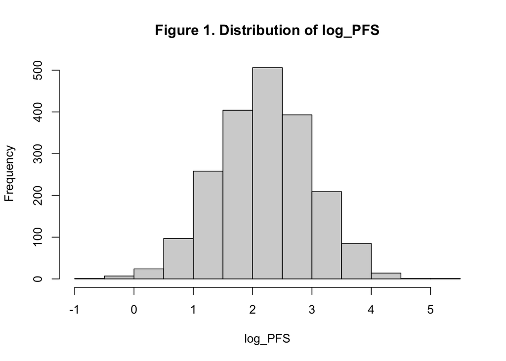

```r
# check outcome distribution
hist(datA$log_PFS, main = "Figure 1. Distribution of log_PFS", xlab = "log_PFS")
```

*Figure 1. Distribution of log_PFS.*

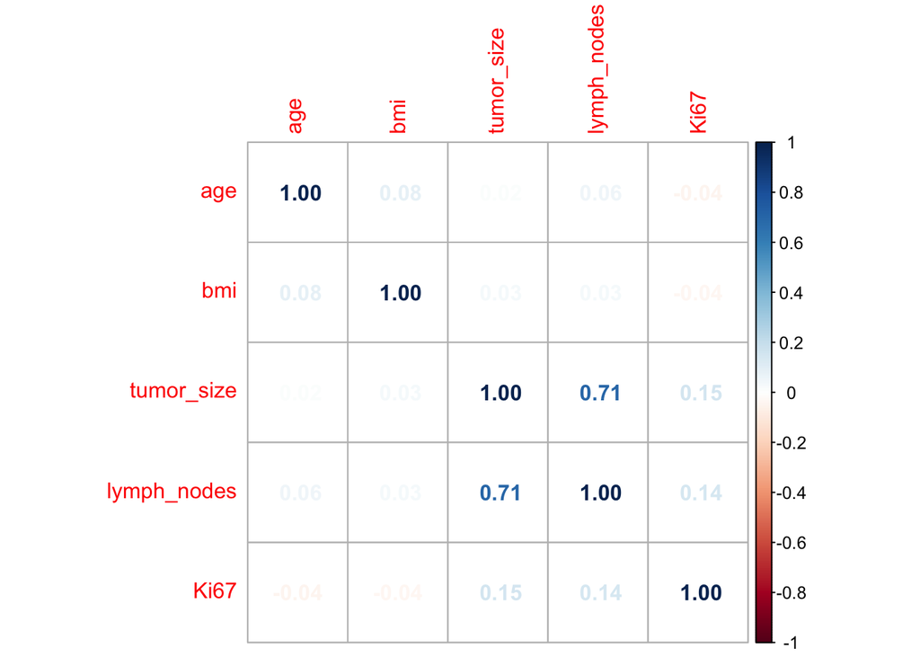

```r
datA |>
  select(age, bmi, tumor_size, lymph_nodes, Ki67) |>
  cor() |>
  corrplot(method = "number")
```

*Figure 2. Correlation matrix of continuous predictors in Dataset A.*

From the correlation plot, it seems that lymph_nodes and tumor_size has a moderate positive correlation r = 0.71 , which makes sense in a clinical context. Everything else seems largely uncorrelated; there is no severe multicollinearity, OLS shouldn’t be too unstable. The mild correlation between lymph_nodes and tumor_size may result in one predictor being dropped by LASSO, so elastic net might be preferred here.

# Train test split + model building

```r
# train test split
set.seed(67)
data_split <- initial_split(datA, prop = 0.8)
training_data <- training(data_split)
testing_data <- testing(data_split)

# train control object
ctrl1 <- trainControl(method = "cv", number = 10, savePredictions = TRUE)
```

# OLS

```r
set.seed(67)

ols_fit <- train(log_PFS ~.,
                 data = training_data,
                 method = "lm",
                 trControl = ctrl1)

summary(ols_fit)
```

```
##
## Call:
## lm(formula = .outcome ~ ., data = dat)
##
## Residuals:
##      Min       1Q   Median       3Q      Max
## -2.73934 -0.47220  0.01116  0.47967  2.69926
##
## Coefficients:
##                     Estimate Std. Error t value Pr(>|t|)
## (Intercept)        2.6949155  0.1585026  17.002  < 2e-16 ***
## age               -0.0030578  0.0021697  -1.409 0.158935
## menopause1         0.0080870  0.0528736   0.153 0.878458
## race2              0.0185149  0.0514667   0.360 0.719086
## race3              0.0505343  0.0635364   0.795 0.426524
## race4             -0.0549394  0.0550933  -0.997 0.318817
## bmi                0.0009555  0.0038984   0.245 0.806417
## tumor_size        -0.0683906  0.0227807  -3.002 0.002723 **
## tumor_grade2      -0.0725526  0.0531183  -1.366 0.172174
## tumor_grade3      -0.1907886  0.0672457  -2.837 0.004609 **
## lymph_nodes       -0.0682214  0.0112258  -6.077 1.53e-09 ***
## ER1                0.2291610  0.0587077   3.903 9.88e-05 ***
## PR1               -0.0120941  0.0439853  -0.275 0.783384
## HER21             -0.1567557  0.0441886  -3.547 0.000400 ***
## Ki67              -0.0043033  0.0022338  -1.926 0.054228 .
## stage2             0.0914317  0.0591274   1.546 0.122220
## stage3             0.1264253  0.1166597   1.084 0.278659
## surgery1           0.0037932  0.0379657   0.100 0.920427
## chemo1            -0.0074195  0.0367723  -0.202 0.840124
## hormonal_therapy1  0.1520678  0.0451454   3.368 0.000774 ***
## ---
## Signif. codes:  0 '***' 0.001 '**' 0.01 '*' 0.05 '.' 0.1 ' ' 1
##
## Residual standard error: 0.7051 on 1580 degrees of freedom
## Multiple R-squared:  0.2112, Adjusted R-squared:  0.2017
## F-statistic: 22.27 on 19 and 1580 DF,  p-value: < 2.2e-16
```

OLS results:

- tumor_size: negative effect, larger tumors -> shorter PFS
- tumor_grade3: negative, poorly differentiated tumors -> shorter PFS
- lymph_nodes: negative, more positive nodes -> shorter PFS
- ER1: positive, ER positive -> longer PFS
- HER21: negative, HER2 positive -> shorter PFS
- hormonal_therapy1: positive, hormonal therapy -> longer PFS
- age, bmi, menopause, race, PR, stage, surgery, chemo not significant in OLS
- Adjusted R^2 = 0.20 : the model explains about 20% of variance in log PFS

# Ridge

```r
set.seed(67)
ridge_fit <- train(log_PFS ~ .,
                   data = training_data,
                   method = "glmnet",
                   tuneGrid = expand.grid(alpha = 0,
                                          lambda = exp(seq(6, -4, length=100))),
                   trControl = ctrl1)
```

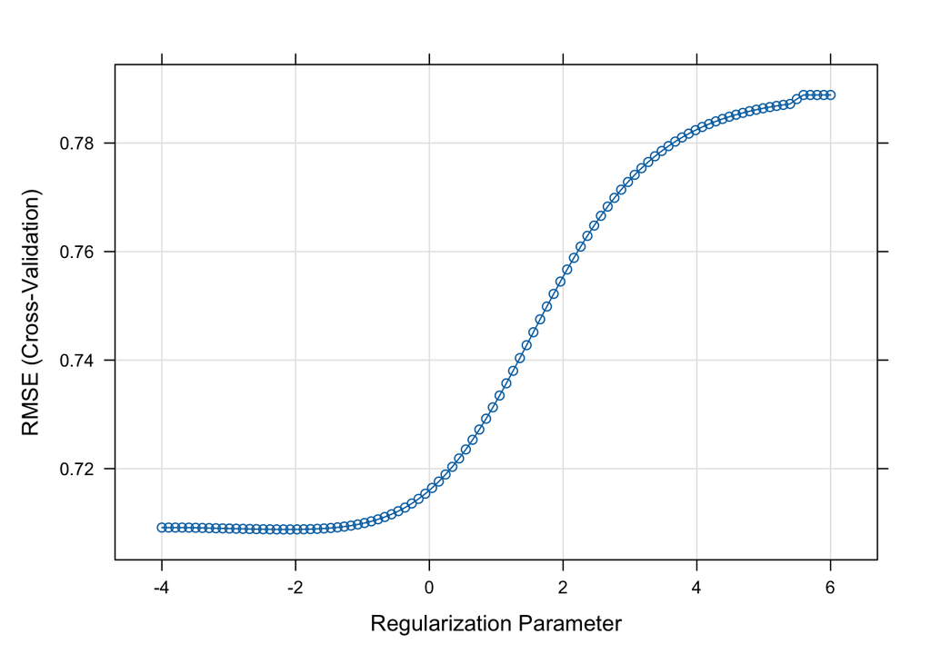

```r
plot(ridge_fit, xTrans = log)
```

```r
ridge_fit$bestTune
```

```
##    alpha    lambda
## 19     0 0.1128362
```

# LASSO

```r
set.seed(67)
lasso_fit <- train(log_PFS ~ .,
                   data = training_data,
                   method = "glmnet",
                   tuneGrid = expand.grid(alpha = 1,
                                          lambda = exp(seq(4, -10, length=100))),
                   trControl = ctrl1)
```

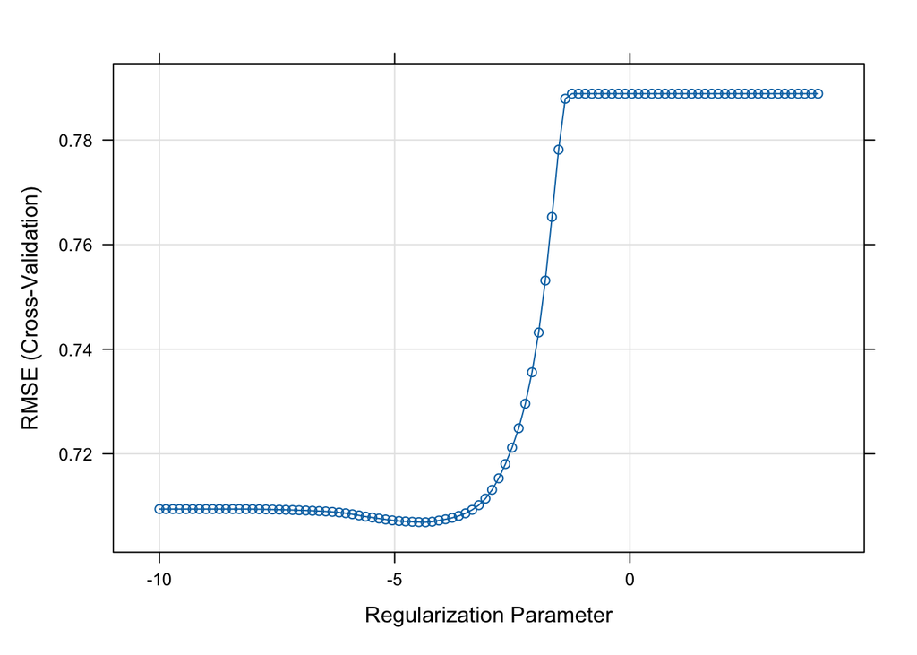

```r
plot(lasso_fit, xTrans = log)
```

```r
lasso_fit$bestTune
```

```
##    alpha     lambda
## 41     1 0.01299183
```

```r
coef(lasso_fit$finalModel, s = lasso_fit$bestTune$lambda)
```

```
## 20 x 1 sparse Matrix of class "dgCMatrix"
##                             s0
## (Intercept)        2.600416237
## age               -0.001738541
## menopause1         .
## race2              .
## race3              0.005695736
## race4             -0.024402590
## bmi                .
## tumor_size        -0.047114496
## tumor_grade2       .
## tumor_grade3      -0.104548373
## lymph_nodes       -0.062144518
## ER1                0.208395550
## PR1                .
## HER21             -0.128160939
## Ki67              -0.005143791
## stage2             0.015762828
## stage3             .
## surgery1           .
## chemo1             .
## hormonal_therapy1  0.136572696
```

LASSO dropped menopause, bmi, tumor_grade2, PR, stage3, surgery, chemo but kept age, race4, tumor_size, tumor_grade3, lymph_nodes, ER1, HER21, Ki67, stage2, hormonal_therapy1, race3. both lymph_nodes and tumor_size were kept, but shrunken compared to OLS.

# Elastic net

```r
set.seed(67)
enet_fit <- train(log_PFS ~ .,
                   data = training_data,
                   method = "glmnet",
                   tuneGrid = expand.grid(alpha = seq(0, 1, length = 21),
                                          lambda = exp(seq(4, -10, length=100))),
                   trControl = ctrl1)
enet_fit$bestTune
```

```
##      alpha     lambda
## 2041     1 0.01299183
```